# Figure 2 - *huva*

Bonaguro et al.

# 1 Figure 2 (Supp. Figures S3,S4)

## 1.1 Loading required packages

```r
library(huva)
library(huva.db)
library(tidyverse)
library(ggplot2)
library(pheatmap)
library(ggsci)
library(fgsea)
library(ggrepel)
library(ggpubr)
```

## 1.2 Costum Functions

```r
scaleColors <- function(data = input_scale, # data to use
                        maxvalue = NULL # value at which the color is fully red / blue
                        ){
  if(is.null(maxvalue)){
    maxvalue <- floor(min(abs(min(data)), max(data)))
  }
  if(max(data) > abs(min(data))){
    if(ceiling(max(data)) == maxvalue){
      myBreaks <- c(floor(-max(data)), seq(-maxvalue+0.2, maxvalue-0.2, 0.2),  ceiling(max(data)))
    } else{
      myBreaks <- c(floor(-max(data)), seq(-maxvalue, maxvalue, 0.2),  ceiling(max(data)))
    }
    paletteLength <- length(myBreaks)
    myColor <- colorRampPalette(c("blue", "white", "red"))(paletteLength)
  } else {
    if(-floor(min(data)) == maxvalue){
      myBreaks <- c(floor(min(data)), seq(-maxvalue+0.2, maxvalue-0.2, 0.2),  ceiling(min(data)))
    } else{
      myBreaks <- c(floor(min(data)), seq(-maxvalue, maxvalue, 0.2),  ceiling(abs(min(data))))
    }
    paletteLength <- length(myBreaks)
    myColor <- colorRampPalette(c("blue", "white", "red"))(paletteLength)
  }
 return(list(breaks = myBreaks, color = myColor))
}
```

## 1.3 *huva GOI experiment* for *MyD88*

First we calculate the *huva* results for the GOI *MyD88* and collect it in a list. This calculation will take longer compared to previous *huva experiment*, this is because here we are calculating the GSEA for the complete MsigDB signature collection and not only for the hallmark genes

```r
set.seed(91)

MYD88 <- list()

MYD88$bin_data <- run_huva_experiment(data = huva.db,
                                      gene = "MYD88",
                                      quantiles = 0.10,
                                      gs_list = msigdb_V7.2,
                                      summ = T,
                                      datasets_list = NULL,
                                      adjust.method = "BH")

MYD88$overview <- gene_exam(huva_dataset = huva.db, gene = "MYD88")
```

### 1.3.1 *MyD88* expression in 500FG cohort

We now want to investigate the distribution of MyD88 expression in the cohort

#### 1.3.1.1 Histogram

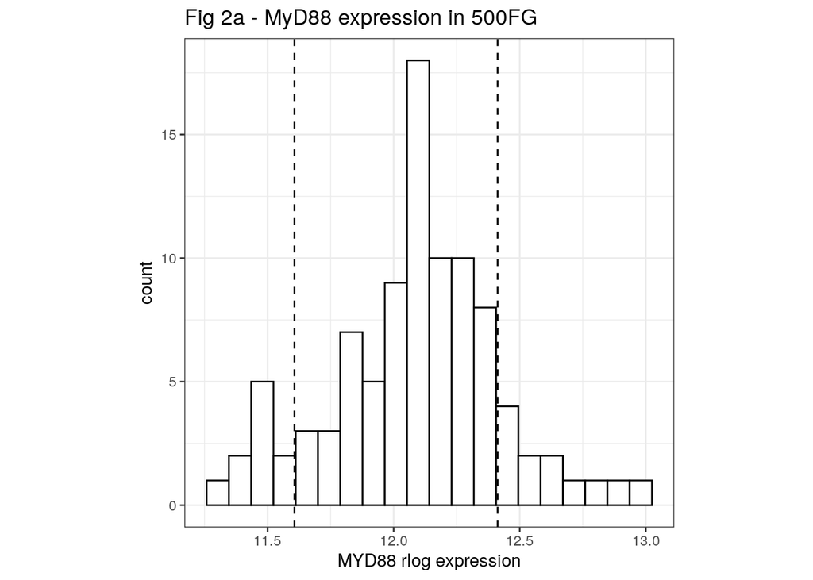

```r
expression <- MYD88$overview$expression$FG500_PBMC

expression$group <- ifelse(expression$expression < quantile(expression$expression, 0.1), "low", ifelse(expression$expression > quantile(expression$expression, 0.9), "high", "none"))

ggplot(expression, aes(x=expression)) +
  geom_histogram(color="black", bins = 20, fill= "white") +
  theme_bw() + theme(aspect.ratio = 1) +
  geom_vline(xintercept =quantile(expression$expression, 0.1), linetype = "dashed") +
  geom_vline(xintercept =quantile(expression$expression, 0.9), linetype = "dashed") +
  ggtitle("Fig 2a - MyD88 expression in 500FG") +
  xlab("MYD88 rlog expression")
```

#### 1.3.1.2 qqplot

To test for normal distribution of the rlog expression we plot the data in a qqplot and perform a Shapiro test for normal distribution (p = 0.2003)

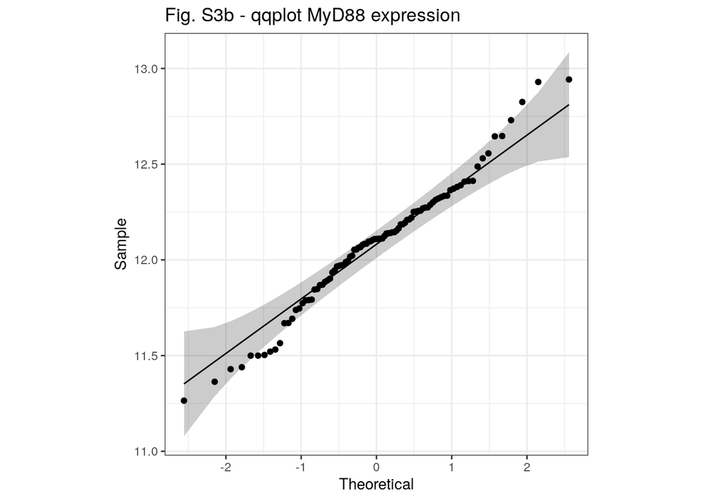

```r
ggqqplot(MYD88$overview$expression$FG500_PBMC$expression) + theme_bw() + theme(aspect.ratio = 1) + ggtitle("Fig. S3b - qqplot MyD88 expression")
```

```r
shapiro.test(MYD88$overview$expression$FG500_PBMC$expression)
```

```
##
##  Shapiro-Wilk normality test
##
## data:  MYD88$overview$expression$FG500_PBMC$expression
## W = 0.98152, p-value = 0.2003
```

#### 1.3.1.3 HIGH and LOW

In the huva experiment we define two groups with high and low expression of MyD88, here we pot in a boxplot the expression of our gene of interest in the two groups.

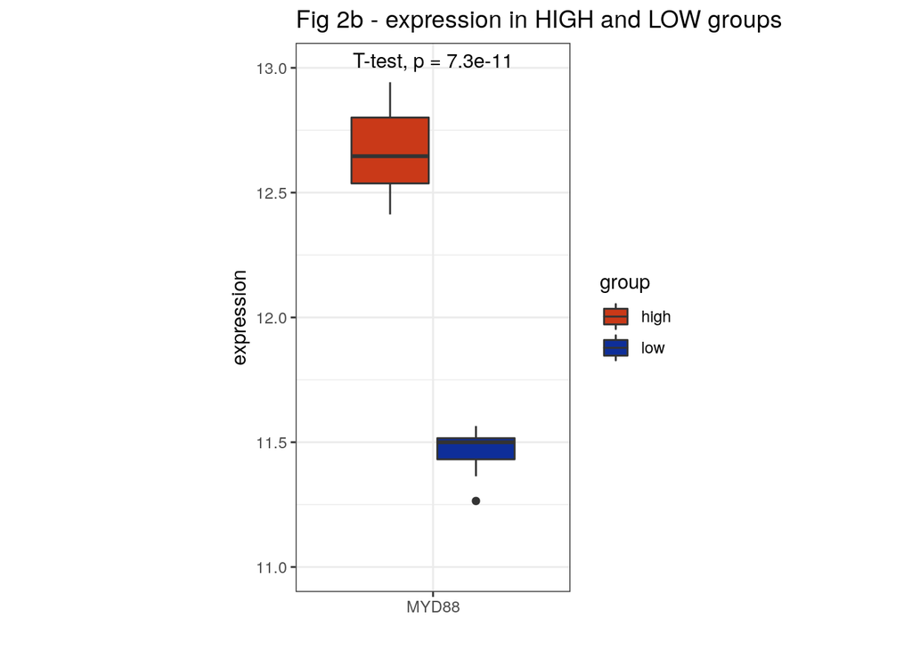

```r
plot_binned <- plot_binned_gene(goi = "MYD88", huva_experiment = MYD88$bin_data)

plot_binned$FG500_PBMC + theme_bw() + theme(aspect.ratio = 2) + scale_y_continuous(limits = c(11, 13)) + ggtitle("Fig 2b - expression in HIGH and LOW groups")
```

### 1.3.2 Comparing the transcriptome

At this stage we analyse the difference between the transcriptome of the HIGH and LOW *MyD88* *huva* groups, at first we look the the principal component analysis.

#### 1.3.2.1 PCA

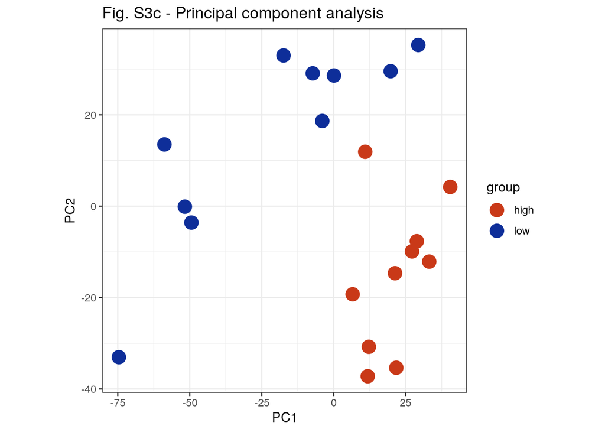

```r
MYD88$DE_genes <- get_DE_huva(huva_exp = MYD88$bin_data, study = "FG500", dataset = "FG500_PBMC", cluster_col = F)

MYD88$DE_genes$PCA_FG500_PBMC + ggtitle("Fig. S3c - Principal component analysis")
```

#### Volcano plot

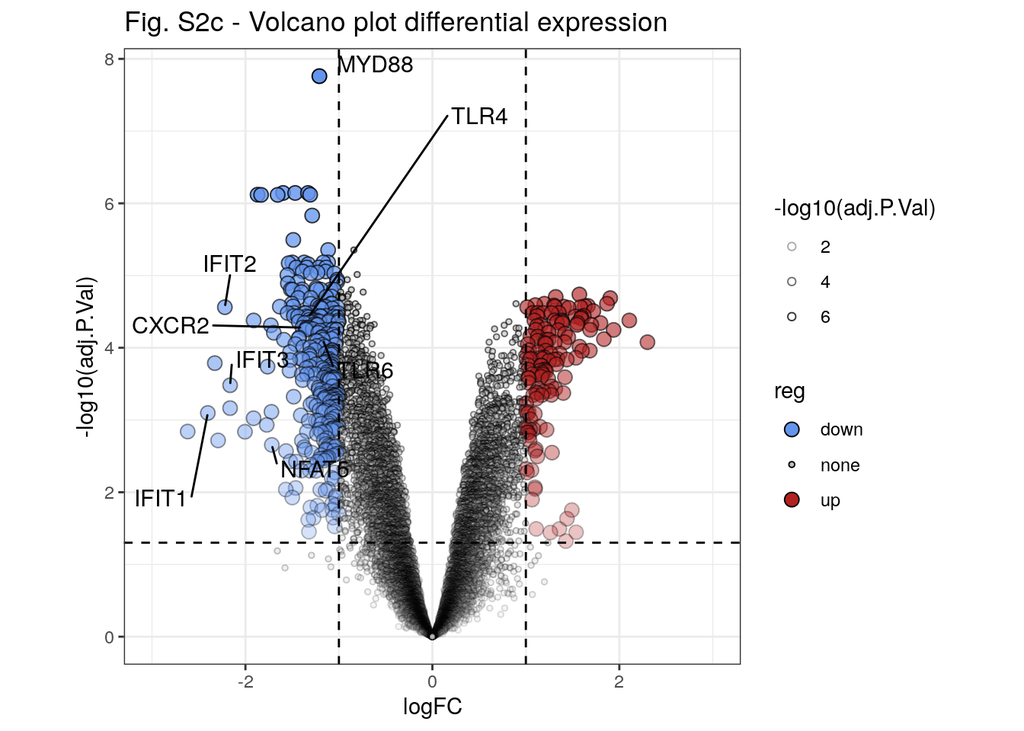

```r
# Preparing the DE genes list filtering for a fold change of 2 and a corrected p value of 0.05
DE_table <- MYD88$bin_data$FG500$DE_genes$FG500_PBMC

DE_table$reg <- ifelse(DE_table$logFC < -1 & DE_table$adj.P.Val < 0.05, "down",
                       ifelse(DE_table$logFC > 1 & DE_table$adj.P.Val < 0.05, "up", "none"))

DE_table$symbol <- rownames(DE_table)

# Manually select which genes to label in the volcano plot
gene.to.label <- c("NFAT5", "IFIT1", "IFIT2", "IFIT3", "CXCR2", "TLR4", "TLR6", "MYD88")

DE_table$label <- ifelse(DE_table$symbol %in% gene.to.label, "T", "F")

ggplot(DE_table, aes(x=logFC, y=-log10(adj.P.Val), alpha =-log10(adj.P.Val), fill=reg, size=reg)) +
  geom_point(shape=21) +
  theme_bw() + theme(aspect.ratio = 1) + scale_x_continuous(limits = c(-3, 3)) +
  geom_vline(xintercept = c(-1, 1) , linetype = "dashed") +
  geom_hline(yintercept = -log10(0.05), linetype = "dashed") +
  scale_fill_manual(values = c("#6495ED", "#BEBEBE", "#B22222")) +
  scale_size_manual(values = c(3,1,3)) +
  geom_text_repel(data=DE_table[!DE_table$label =="F",],aes(label=symbol), size=4, alpha=1, force = 100) +
  ggtitle("Fig. S2c - Volcano plot differential expression")
```

#### 1.3.2.2 Barplot of DE genes

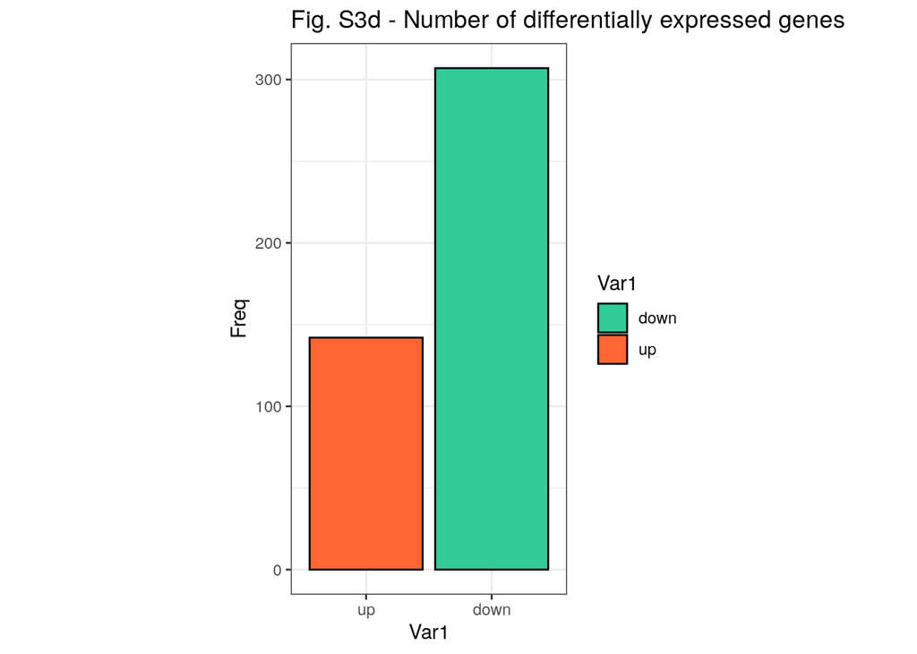

```r
bar_DE <- as.data.frame(table(DE_table$reg))
bar_DE <- bar_DE[bar_DE$Var1 %in% c("up", "down"), ]

ggplot(bar_DE, aes(x=Var1, y=Freq, fill=Var1)) +
  geom_bar(stat = "identity", color = "black") +
  scale_x_discrete(limits = c("up", "down")) +
  theme_bw() + theme(aspect.ratio = 2) +
  scale_fill_manual(values = c("#33CC99", "#FF6633")) +
  ggtitle("Fig. S3d - Number of differentially expressed genes")
```

#### 1.3.2.3 Heatmap of DE genes

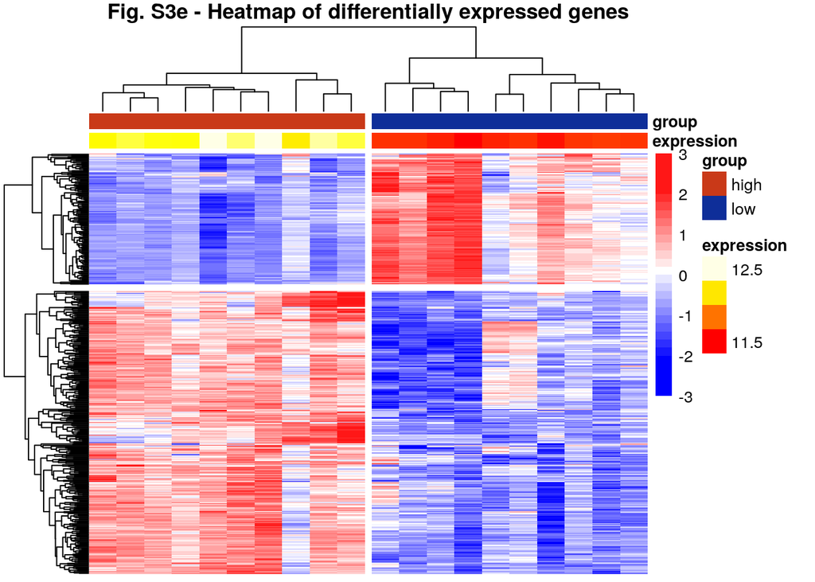

```r
anno <- MYD88$bin_data$FG500$anno$FG500_PBMC
data <- MYD88$bin_data$FG500$data$FG500_PBMC

rownames(anno) <- anno$Row.names

data <- data[rownames(DE_table[DE_table$reg != "none",]),]

data <- t(scale(t(data)))

pheatmap(mat = data,
         scale = "none",
         cluster_rows = T,
         cluster_cols = T,
         annotation = anno[, c(2,3)],
         annotation_colors = list(group=c(high="#c93918", low="#0e2e99"),
         expression=heat.colors(20, alpha = 1)), show_rownames = F, show_colnames = F,
         breaks = scaleColors(data = data, maxvalue = NULL)[["breaks"]],
         color = scaleColors(data = data, maxvalue = NULL)[["color"]], cutree_rows = 2, cutree_cols = 2,
         main = "Fig. S3e - Heatmap of differentially expressed genes")
```

### 1.3.3 Phenotypic changes

myd88 is important for the production of cytokines and TLR signalling

```r
meta_stat <- get_meta.stat_huva(huva_exp = MYD88$bin_data, study = "FG500")

# Assign the measured cytokine to the data
meta_stat$FG500_PBMC_cytokines$type <- unlist(lapply(strsplit(as.character(meta_stat$FG500_PBMC_cytokines$variable), split = "_"), `[[`, 1))

# Assaign the main cell type to the data
meta_stat$FG500_PBMC_cellcount$type <- c("B_cell", "B_cell","B_cell","B_cell","B_cell", "T_cell", "T_cell", "T_cell", "T_cell", "T_cell", "T_cell", "T_cell", "T_cell", "T_cell", "T_cell", "T_cell", "T_cell", "T_cell", "T_cell", "T_cell", "T_cell", "T_cell", "T_cell", "T_cell", "T_cell", "T_cell", "T_cell", "B_cell", "B_cell", "Monocytes", "T_cell", "T_cell", "Granulocytes", "B_cell", "B_cell", "B_cell", "B_cell", "B_cell", "B_cell", "B_cell", "B_cell", "B_cell", "B_cell", "B_cell", "B_cell", "B_cell", "B_cell", "B_cell", "B_cell", "Monocytes", "T_cell", "B_cell", "Monocytes", "B_cell", "B_cell", "B_cell", "NK_cell", "NK_cell","NK_cell","NK_cell", "Monocytes", "B_cell", "T_cell", "T_cell", "T_cell", "T_cell", "T_cell", "T_cell", "T_cell", "B_cell", "T_cell", "T_cell", "T_cell", "T_cell")
```

#### 1.3.3.1 Cell count - Volcano

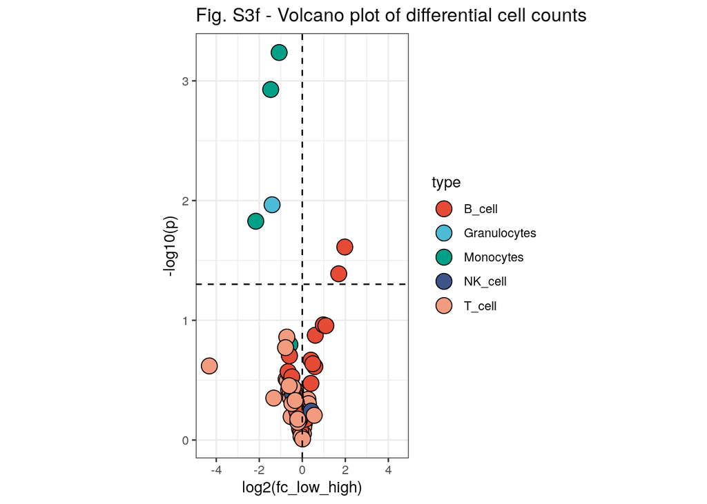

```r
ggplot(meta_stat$FG500_PBMC_cellcount, aes(x=log2(fc_low_high), y=-log10(p), fill = type)) +
  geom_point(shape=21, size=5) +
  theme_bw() + theme(aspect.ratio = 2) +
  geom_vline(xintercept = 0, linetype = "dashed") +
  geom_hline(yintercept = -log10(0.05), linetype = "dashed") +
  scale_x_continuous(limits = c(-4.5,4.5), breaks = c(-4, -2, 0, 2,4)) +
  scale_fill_npg() + ggtitle("Fig. S3f - Volcano plot of differential cell counts")
```

#### Cytokines - Volcano

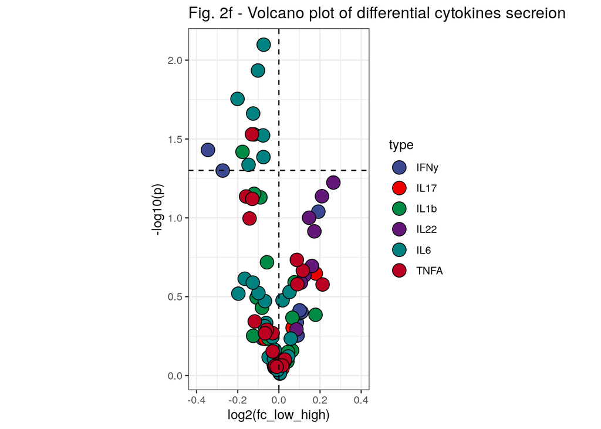

```r
ggplot(meta_stat$FG500_PBMC_cytokines, aes(x=log2(fc_low_high), y=-log10(p), fill = type)) +
  geom_point(shape=21, size=5) +
  scale_x_continuous(limits = c(-0.4,0.4)) +
  theme_bw() + theme(aspect.ratio = 2) +
  geom_vline(xintercept = 0, linetype = "dashed") +
  geom_hline(yintercept = -log10(0.05), linetype = "dashed") +
  scale_fill_aaas() + ggtitle("Fig. 2f - Volcano plot of differential cytokines secreion")
```

#### Monocytes - Boxplot

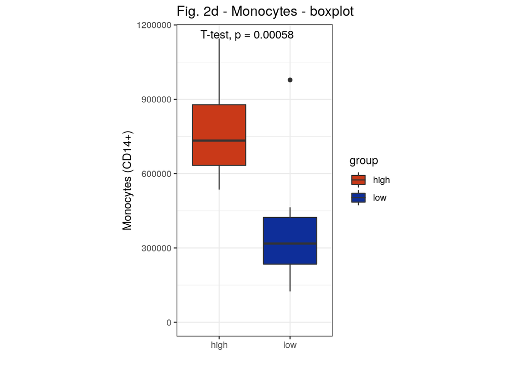

```r
meta_plot <- get_meta.plot_huva(MYD88$bin_data, study = "FG500")

meta_plot$FG500_PBMC_cellcount$`Monocytes (CD14+)` + theme_bw() + theme(aspect.ratio = 2) +
  expand_limits(y=0) + ggtitle("Fig. 2d - Monocytes - boxplot")
```

#### 1.3.3.2 Classical monocytes - Boxplot

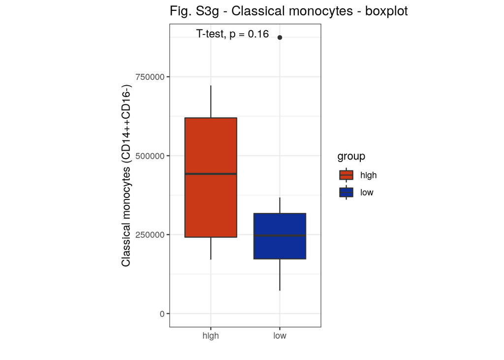

```r
meta_plot$FG500_PBMC_cellcount$`Classical monocytes (CD14++CD16-)` + theme_bw() + theme(aspect.ratio = 2) +
  expand_limits(y=0) + ggtitle("Fig. S3g - Classical monocytes - boxplot")
```

#### 1.3.3.3 Non-classical monocytes - Boxplot

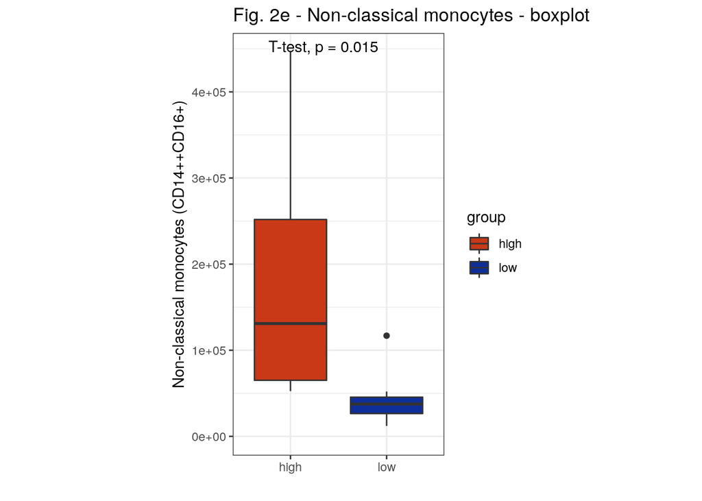

```r
meta_plot$FG500_PBMC_cellcount$`Non-classical monocytes (CD14++CD16+)` + theme_bw() + theme(aspect.ratio = 2) +
  expand_limits(y=0) + ggtitle("Fig. 2e - Non-classical monocytes - boxplot")
```

#### 1.3.3.4 Int. monocytes - Boxplot

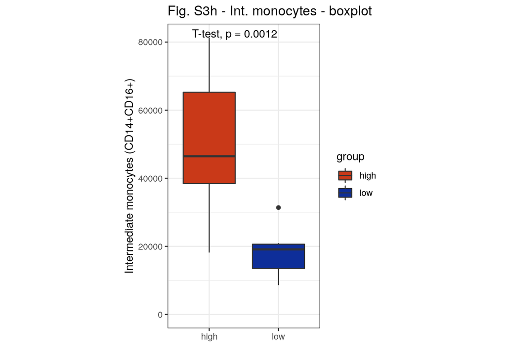

```r
meta_plot$FG500_PBMC_cellcount$`Intermediate monocytes (CD14+CD16+)` + theme_bw() + theme(aspect.ratio = 2) +
  expand_limits(y=0) + ggtitle("Fig. S3h - Int. monocytes - boxplot")
```

#### 1.3.3.5 IL6 - LPS - boxplot

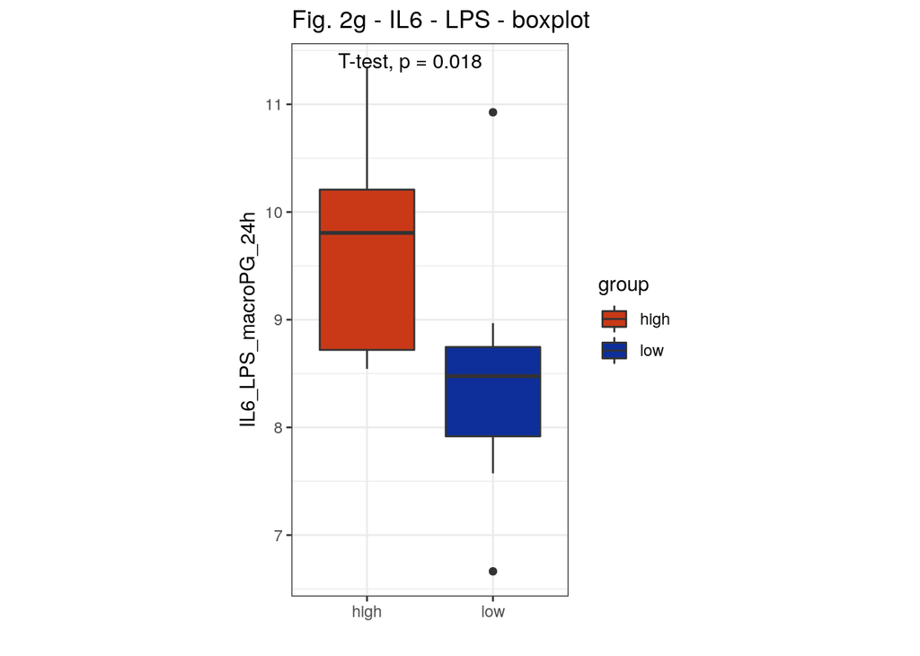

```r
meta_plot$FG500_PBMC_cytokines$IL6_LPS_macroPG_24h + theme_bw() +
  theme(aspect.ratio = 2) + ggtitle("Fig. 2g - IL6 - LPS - boxplot")
```

#### 1.3.3.6 IL6 - CpG - Boxplot

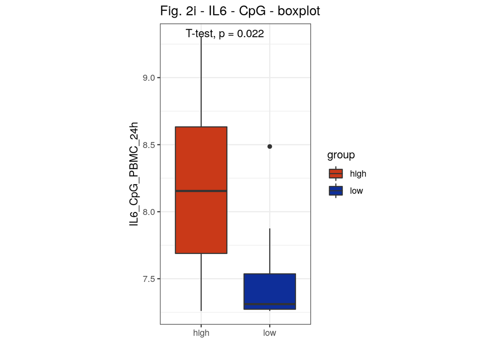

```r
meta_plot$FG500_PBMC_cytokines$IL6_CpG_PBMC_24h + theme_bw() +
  theme(aspect.ratio = 2) + ggtitle("Fig. 2i - IL6 - CpG - boxplot")
```

#### 1.3.3.7 IL6 - Pam3Cys - Boxplot

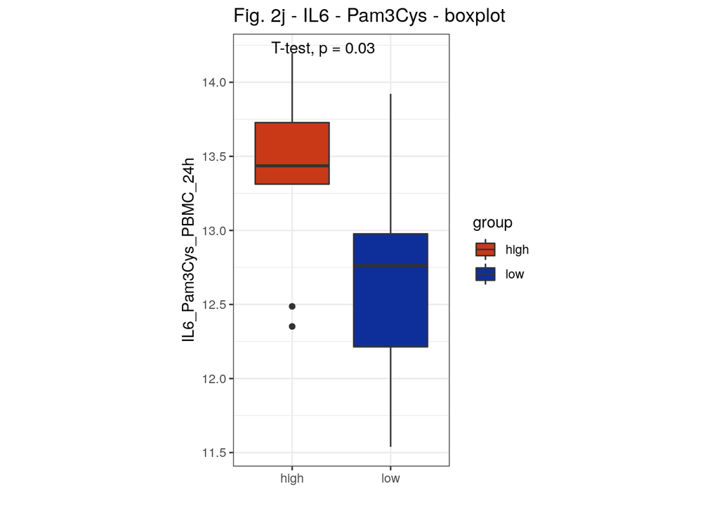

```r
meta_plot$FG500_PBMC_cytokines$IL6_Pam3Cys_PBMC_24h + theme_bw() +
  theme(aspect.ratio = 2) + ggtitle("Fig. 2j - IL6 - Pam3Cys - boxplot")
```

### 1.3.4 GSEA of *MyD88* related signatures

#### 1.3.4.1 Volcano plot of selected signatures

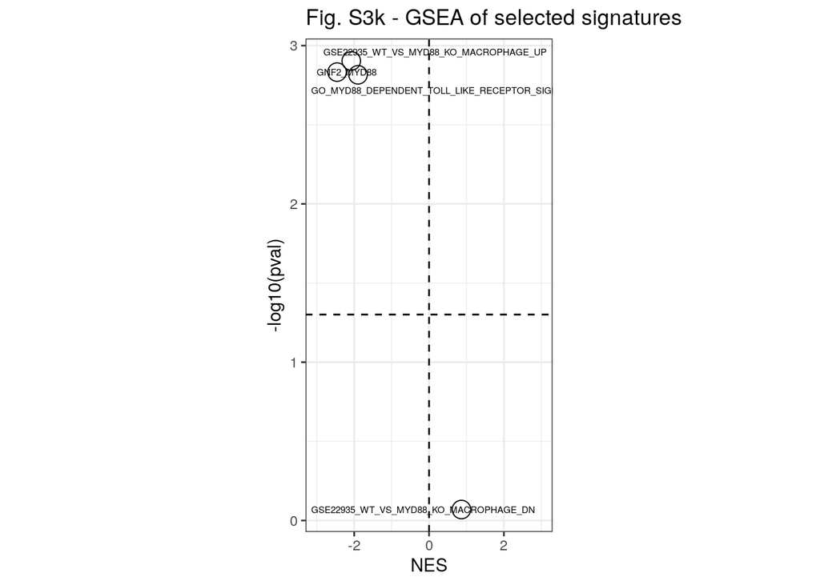

```r
gsea <- MYD88$bin_data$FG500$gsea$FG500_PBMC

gsea <- gsea[c(1215,9842,9843,12203),]

ggplot(gsea, aes(x=NES, y=-log10(pval), label = pathway)) +
  geom_point(shape = 21, size = 5) +
  theme_bw() + theme(aspect.ratio = 2) +
  scale_x_continuous(limits = c(-3, 3)) +
  geom_vline(xintercept = 0, linetype = "dashed") +
  geom_hline(yintercept = -log10(0.05), linetype = "dashed") +
  geom_text_repel(size = 2) + ggtitle("Fig. S3k - GSEA of selected signatures")
```

#### 1.3.4.2 GNF2 MYD88 Enrichment

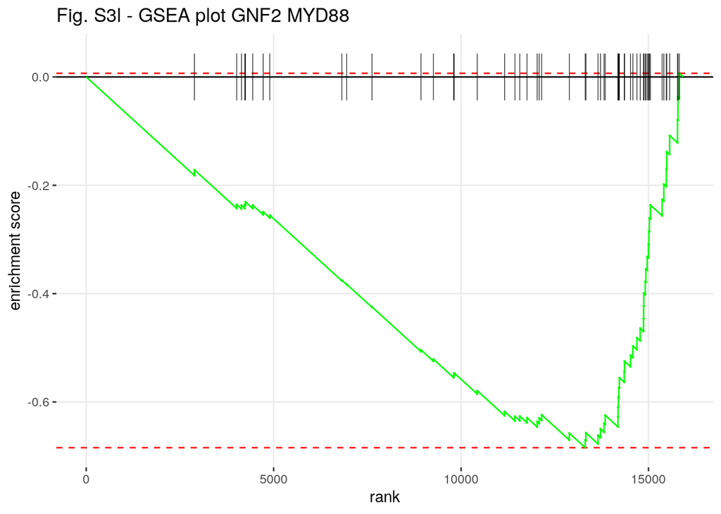

```r
plotEnrichment(msigdb_V7.2$GNF2_MYD88,
               MYD88$bin_data$FG500$Rank_genelist$FG500_PBMC) + labs(title="GNF2 MYD88") + ggtitle("Fig. S3l - GSEA plot GNF2 MYD88")
```

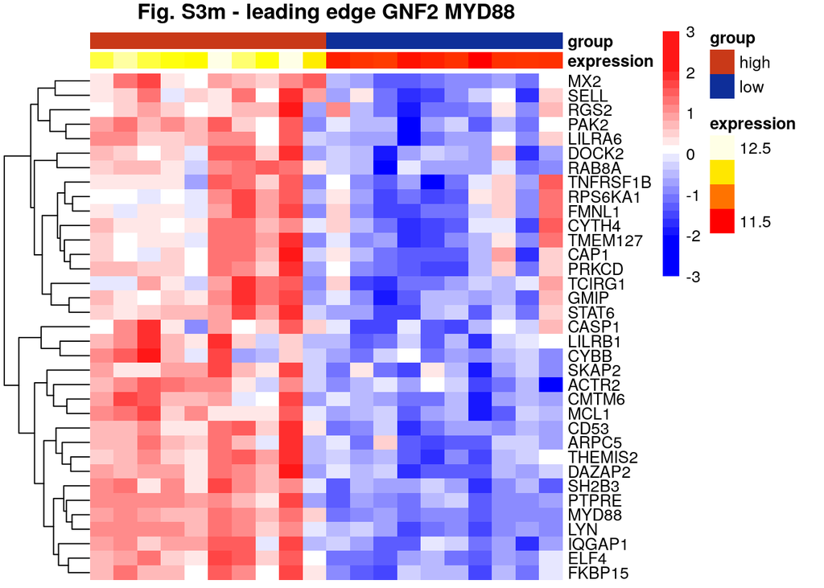

```r
anno <- MYD88$bin_data$FG500$anno$FG500_PBMC
data <- MYD88$bin_data$FG500$data$FG500_PBMC

rownames(anno) <- anno$Row.names

anno <- anno[order(anno$group),]

data <- data[rownames(data) %in% unlist(gsea[gsea$pathway=="GNF2_MYD88",]$leadingEdge),]

data <- data[, anno$Row.names]

data <- t(scale(t(data)))

pheatmap(mat = data,
         scale = "none",
         cluster_rows = T,
         cluster_cols = F,
         annotation = anno[, c(2,3)],
         annotation_colors = list(group=c(high="#c93918", low="#0e2e99"),
         expression=heat.colors(20, alpha = 1)), show_rownames = T, show_colnames = F, border_color = NA,
         breaks = scaleColors(data = data, maxvalue = NULL)[["breaks"]],
         color = scaleColors(data = data, maxvalue = NULL)[["color"]], main = "Fig. S3m - leading edge GNF2 MYD88")
```

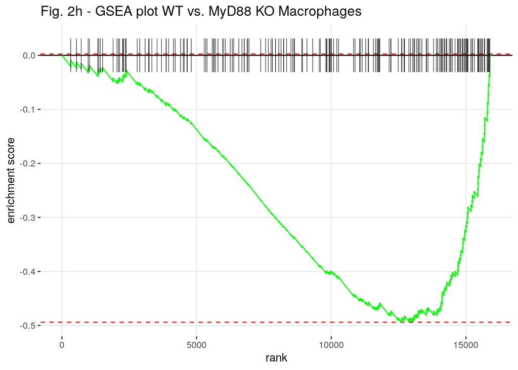

```r
plotEnrichment(msigdb_V7.2$GSE22935_WT_VS_MYD88_KO_MACROPHAGE_UP,
               MYD88$bin_data$FG500$Rank_genelist$FG500_PBMC) + labs(title="WT vs. MyD88 KO Macrophages") +
                ggtitle("Fig. 2h - GSEA plot WT vs. MyD88 KO Macrophages")
```

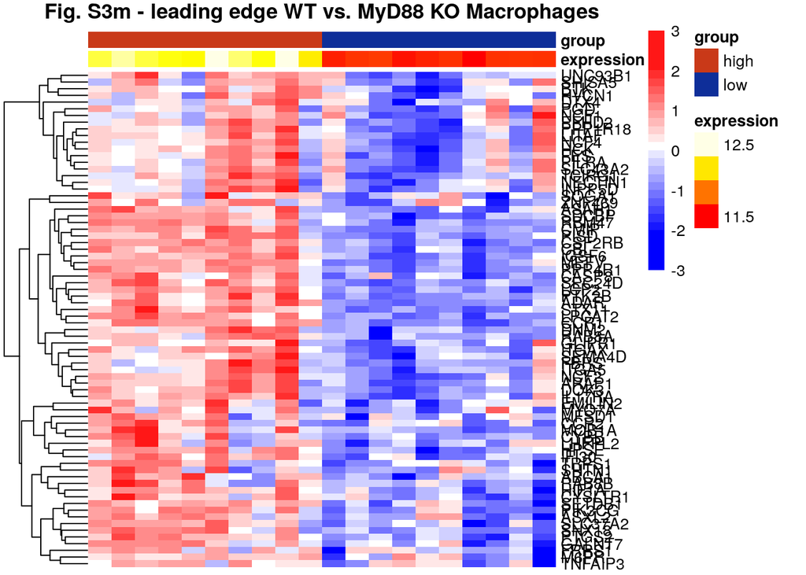

```r
anno <- MYD88$bin_data$FG500$anno$FG500_PBMC
data <- MYD88$bin_data$FG500$data$FG500_PBMC

rownames(anno) <- anno$Row.names

anno <- anno[order(anno$group),]

data <- data[rownames(data) %in% unlist(gsea[gsea$pathway=="GSE22935_WT_VS_MYD88_KO_MACROPHAGE_UP",]$leadingEdge),]

data <- data[, anno$Row.names]

data <- t(scale(t(data)))

pheatmap(mat = data,
         scale = "row",
         cluster_rows = T,
         cluster_cols = F,
         annotation = anno[, c(2,3)],
         annotation_colors = list(group=c(high="#c93918", low="#0e2e99"),
         expression=heat.colors(20, alpha = 1)), show_rownames = T, show_colnames = F, border_color = NA,
         breaks = scaleColors(data = data, maxvalue = NULL)[["breaks"]],
         color = scaleColors(data = data, maxvalue = NULL)[["color"]], main = "Fig. S3m - leading edge WT vs. MyD88 KO Macrophages")
```

## 1.4 Analysis of additional genes

### 1.4.1 AKT

#### 1.4.1.1 *huva GOI experiment*

```r
set.seed(91)

AKT <- list()

AKT$bin_data <- run_huva_experiment(data = huva.db,
                                      gene = "AKT1",
                                      quantiles = 0.10,
                                      gs_list = msigdb_V7.2,
                                      summ = T,
                                      datasets_list = NULL,
                                      adjust.method = "BH")

AKT$overview <- gene_exam(huva_dataset = huva.db, gene = "AKT1")
```

#### 1.4.1.2 AKT_UP.V1_UP enrichment

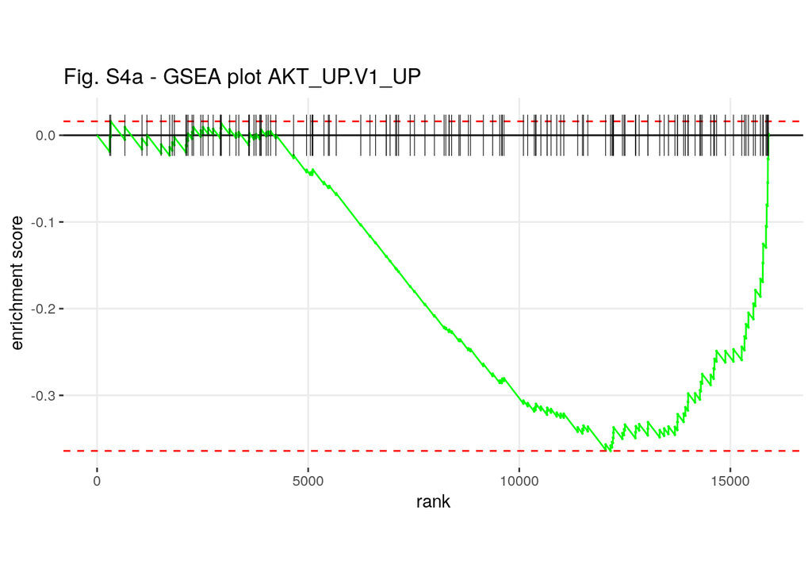

```r
gsea <- AKT$bin_data$FG500$gsea$FG500_PBMC

plotEnrichment(msigdb_V7.2$AKT_UP.V1_UP,
               AKT$bin_data$FG500$Rank_genelist$FG500_PBMC) + labs(title="AKT_UP.V1_UP") + theme(aspect.ratio = 1/2) +
  ggtitle("Fig. S4a - GSEA plot AKT_UP.V1_UP")
```

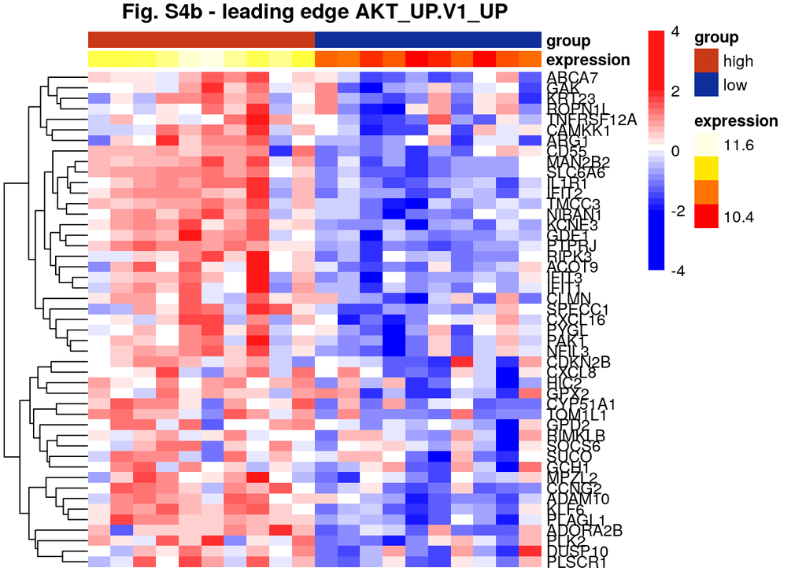

```r
anno <- AKT$bin_data$FG500$anno$FG500_PBMC
data <- AKT$bin_data$FG500$data$FG500_PBMC

rownames(anno) <- anno$Row.names

anno <- anno[order(anno$group),]

data <- data[rownames(data) %in% unlist(gsea[gsea$pathway=="AKT_UP.V1_UP",]$leadingEdge),]

data <- data[, anno$Row.names]

data <- t(scale(t(data)))

pheatmap(mat = data,
         scale = "none",
         cluster_rows = T,
         cluster_cols = F,
         annotation = anno[, c(2,3)],
         annotation_colors = list(group=c(high="#c93918", low="#0e2e99"),
         expression=heat.colors(20, alpha = 1)), show_rownames = T, show_colnames = F, border_color = NA,
         breaks = scaleColors(data = data, maxvalue = NULL)[["breaks"]],
         color = scaleColors(data = data, maxvalue = NULL)[["color"]], main = "Fig. S4b - leading edge AKT_UP.V1_UP")
```

### ERK (MAPK3)

#### 1.4.1.3 *huva GOI experiment*

```r
set.seed(91)

ERK1 <- list()

ERK1$bin_data <- run_huva_experiment(data = huva.db,
                                      gene = "MAPK3",
                                      quantiles = 0.10,
                                      gs_list = msigdb_V7.2,
                                      summ = T,
                                      datasets_list = NULL,
                                      adjust.method = "BH")

ERK1$overview <- gene_exam(huva_dataset = huva.db, gene = "MAPK3")
```

#### 1.4.1.4 GO_ERK1_AND_ERK2_CASCADE enrichment

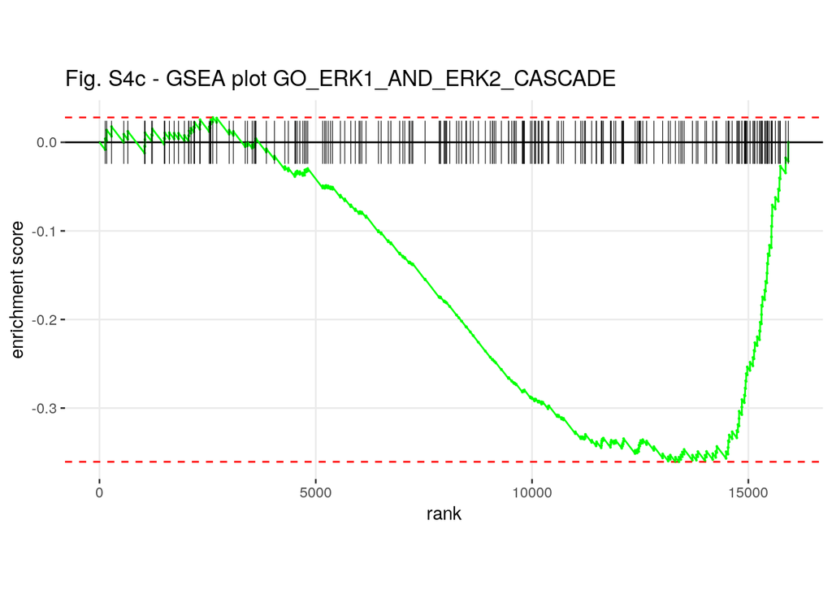

```r
gsea <- ERK1$bin_data$FG500$gsea$FG500_PBMC

plotEnrichment(msigdb_V7.2$GO_ERK1_AND_ERK2_CASCADE,
               ERK1$bin_data$FG500$Rank_genelist$FG500_PBMC) + labs(title="GO_ERK1_AND_ERK2_CASCADE") + theme(aspect.ratio = 1/2) +
  ggtitle("Fig. S4c - GSEA plot GO_ERK1_AND_ERK2_CASCADE")
```

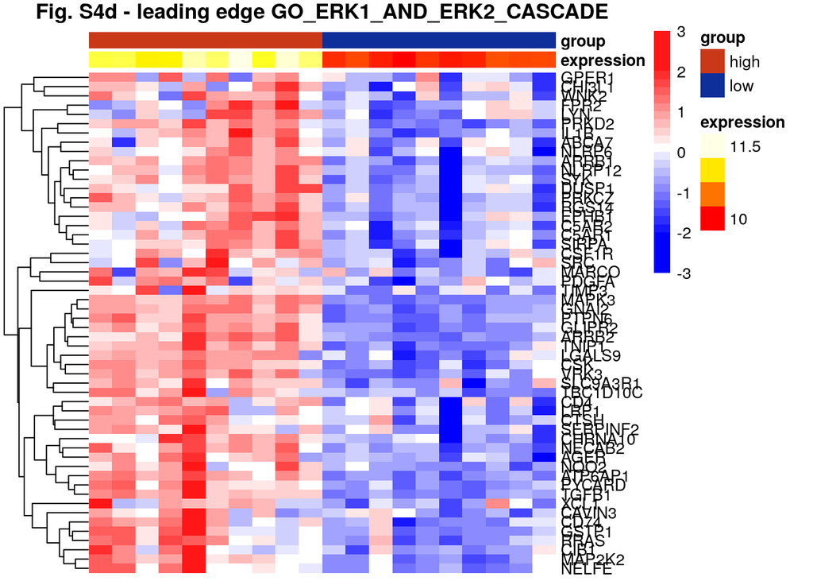

```r
anno <- ERK1$bin_data$FG500$anno$FG500_PBMC
data <- ERK1$bin_data$FG500$data$FG500_PBMC

rownames(anno) <- anno$Row.names

anno <- anno[order(anno$group),]

data <- data[rownames(data) %in% unlist(gsea[gsea$pathway=="GO_ERK1_AND_ERK2_CASCADE",]$leadingEdge),]

data <- data[, anno$Row.names]

data <- t(scale(t(data)))

pheatmap(mat = data,
         scale = "none",
         cluster_rows = T,
         cluster_cols = F,
         annotation = anno[, c(2,3)],
         annotation_colors = list(group=c(high="#c93918", low="#0e2e99"),
         expression=heat.colors(20, alpha = 1)), show_rownames = T, show_colnames = F, border_color = NA,
         breaks = scaleColors(data = data, maxvalue = NULL)[["breaks"]],
         color = scaleColors(data = data, maxvalue = NULL)[["color"]], main = "Fig. S4d - leading edge GO_ERK1_AND_ERK2_CASCADE")
```

### 1.4.2 STAT1

#### 1.4.2.1 *huva GOI experiment*

```r
set.seed(91)

STAT1 <- list()

STAT1$bin_data <- run_huva_experiment(data = huva.db,
                                      gene = "STAT1",
                                      quantiles = 0.10,
                                      gs_list = msigdb_V7.2,
                                      summ = T,
                                      datasets_list = NULL,
                                      adjust.method = "BH")

STAT1$overview <- gene_exam(huva_dataset = huva.db, gene = "STAT1")
```

#### 1.4.2.2 GSE40666_WT_VS_STAT1_KO_CD8_TCELL_UP enrichment

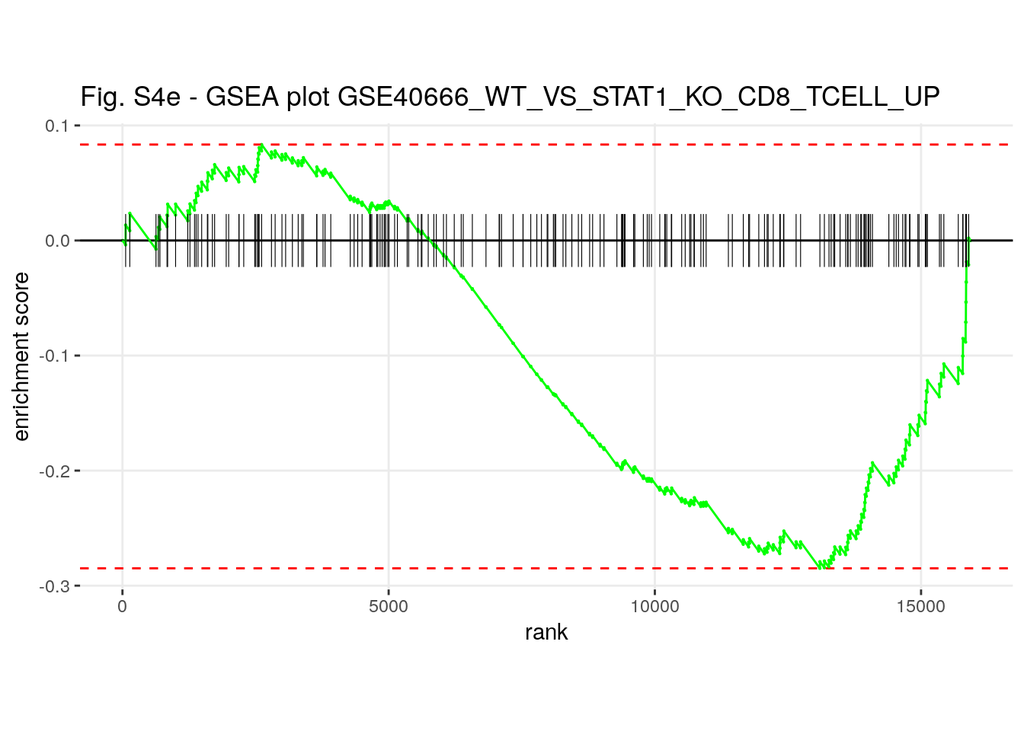

```r
gsea <- STAT1$bin_data$FG500$gsea$FG500_PBMC

plotEnrichment(msigdb_V7.2$GSE40666_WT_VS_STAT1_KO_CD8_TCELL_UP,
               STAT1$bin_data$FG500$Rank_genelist$FG500_PBMC) + labs(title="GSE40666_WT_VS_STAT1_KO_CD8_TCELL_UP") + theme(aspect.ratio = 1/2) +
  ggtitle("Fig. S4e - GSEA plot GSE40666_WT_VS_STAT1_KO_CD8_TCELL_UP")
```

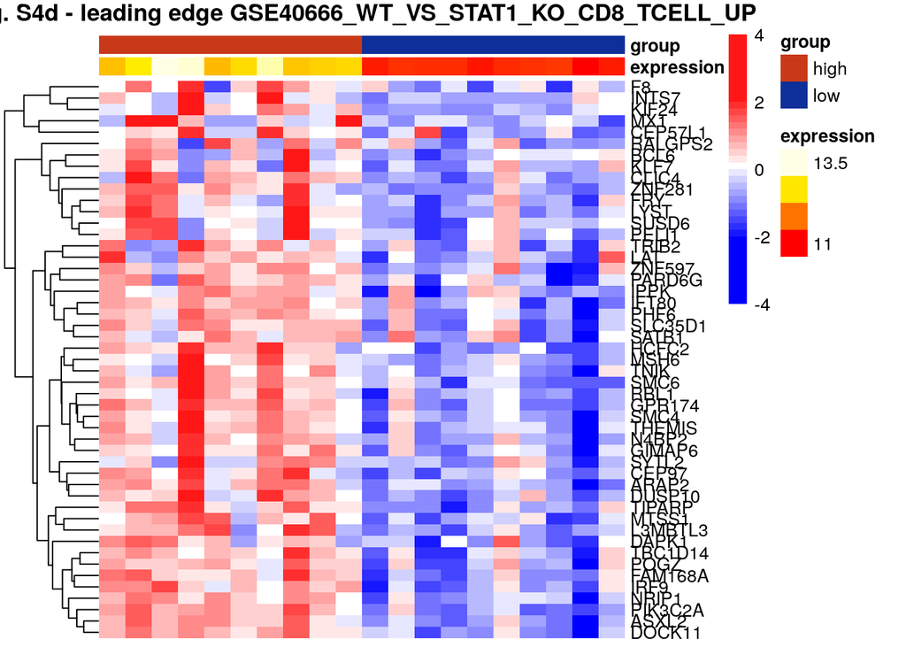

```r
anno <- STAT1$bin_data$FG500$anno$FG500_PBMC
data <- STAT1$bin_data$FG500$data$FG500_PBMC

rownames(anno) <- anno$Row.names

anno <- anno[order(anno$group),]

data <- data[rownames(data) %in% unlist(gsea[gsea$pathway=="GSE40666_WT_VS_STAT1_KO_CD8_TCELL_UP",]$leadingEdge),]

data <- data[, anno$Row.names]

data <- t(scale(t(data)))

pheatmap(mat = data,
         scale = "none",
         cluster_rows = T,
         cluster_cols = F,
         annotation = anno[, c(2,3)],
         annotation_colors = list(group=c(high="#c93918", low="#0e2e99"),
         expression=heat.colors(20, alpha = 1)), show_rownames = T, show_colnames = F, border_color = NA,
         breaks = scaleColors(data = data, maxvalue = NULL)[["breaks"]],
         color = scaleColors(data = data, maxvalue = NULL)[["color"]], main = "Fig. S4d - leading edge GSE40666_WT_VS_STAT1_KO_CD8_TCELL_UP")
```

## 1.5 Clean the env

```r
rm(anno, bar_DE, data, DE_table, expression, gsea, meta_plot, meta_stat, plot_binned, gene.to.label)
```

# 2 Session info

```r
info
```

[output not shown]

# 3 Save environment

```r
save.image(paste("./data/",Sys.Date(), "_huva_Figure_2.RData", sep = ""))
```